# Štatistické metódy vyhodnocovania experimentov

5. Testovanie závislosti kvantitatívnej od kvalitatívnej premennej

Tomáš Bacigál

23.3.2021

```r
`%>%` <- magrittr::`%>%`  # pipe operator
```

# 4 Testovanie štatistických hypotéz

Technicky, testovanie štat.hypotéz a konštrukcia intervalov spoľahlivosti používa rovnaký postup, rozdiel je len v závere. Pri testovaní nás zaujíma odpoveď na otázku: dá sa na základe dostupných pozorovaní zamietnuť (nulová) hypotéza?

## 4.1 Dvojvýberové parametrické testy o parametroch normálneho rozdelenia

### 4.1.1 Nezávislé pozorovania

**Príklad** (Markechová 2011a, Príklad 6.14, str. 141)

Treba overiť efektívnosť nového spôsobu výučby vybraných tematických celkov matematiky. Preto výučba matematiky bola realizovaná v jednej triede experimentálnym spôsobom. Z tejto triedy boli náhodne vybraní žiaci, ktorí budú predstavovať experimentálnu skupinu. Žiaci z experimentálnej skupiny dosiahli v záverečnom teste, ktorý písali po realizácii experimentu, nasledujúce počty bodov: 22, 34, 26, 31, 26, 35, 25, 38, 36, 22, 23, 32. V ostatných triedach prebiehala výučba matematiky štandardným spôsobom. Z týchto tried boli náhodne vybraní žiaci, ktorí tvoria kontrolnú skupinu. Dosiahli v záverečnom teste nasledujúce počty bodov: 24, 33, 23, 20, 26, 32, 35, 21, 25.

```r
x <- c(22, 34, 26, 31, 26, 35, 25, 38, 36, 22, 23, 32)
y <- c(24, 33, 23, 20, 26, 32, 35, 21, 25)
```

F-test rovnosti rozptylov

```r
sx2 <- var(x)
sy2 <- var(y)
TS <- sx2/sy2
c(F_test_statistika = TS,
  krit_hodnota = qf(0.975, df1 = 11, df2 = 8),
  p_hodnota = pf(1/TS, df1 = 11, df2 = 8) + 1 - pf(TS, df1 = 11, df2 = 8)
)
```

```
## F_test_statistika      krit_hodnota         p_hodnota
##         1.1346676         4.2434128         0.8516227
```

t-test stredných hodnôt

```r
( sp2 <- (11*sx2+8*sy2)/(12+9-2) )  # pooled variance
```

```
## [1] 32.09942
```

```r
TS <- (mean(x)-mean(y)) / sqrt(sp2*(1/12+1/9))  # testovacia štatistika
c(T_test_statistika = TS,
  krit_hodnota = qt(0.95, df = 12+9-2),  # jednostranný test
  p_hodnota = 1 - pt(TS, df=12+9-2)
)
```

```
## T_test_statistika      krit_hodnota         p_hodnota
##         1.0451510         1.7291328         0.1545343
```

```r
# vstavanými funkciami
var.test(x,y)
```

```
##
##  F test to compare two variances
##
## data:  x and y
## F = 1.1347, num df = 11, denom df = 8, p-value = 0.8796
## alternative hypothesis: true ratio of variances is not equal to 1
## 95 percent confidence interval:
##  0.267395 4.157217
## sample estimates:
## ratio of variances
##           1.134668
```

Nezamietame H0 o rovnosti rozptylov

```r
t.test(x, y, alternative = "greater", var.equal = TRUE)
```

```
##
##  Two Sample t-test
##
## data:  x and y
## t = 1.0452, df = 19, p-value = 0.1545
## alternative hypothesis: true difference in means is greater than 0
## 95 percent confidence interval:
##  -1.708799       Inf
## sample estimates:
## mean of x mean of y
##  29.16667  26.55556
```

**Príklad** (6.19 Mar11):

Je potrebné overiť, či sa u osobného automobilu určitej značky pri správnej geometrii kolies ojazdia obe pneumatiky rovnako rýchlo. Preto bolo náhodne vybraných 6 nových áut a po určitej dobe bolo zistené, o koľko milimetrov sa ojazdili ich pravé a ľavé predné pneumatiky. Výsledky zisťovania sú uvedené v nasledujúcej tabuľke.

auto 1 2 3 4 5 6  
x 1,8 1,0 2,2 0,9 1,5 1,6  
y 1,5 1,1 2,0 1,1 1,4 1,4  
x, y označuje počet milimetrov, o ktorý sa ojazdili pravé resp. ľavé pneumatiky;

```r
x <- c(1.8,1.0,2.2,0.9,1.5,1.6)
y <- c(1.5,1.1,2.0,1.1,1.4,1.4)
```

Úloha sa zredukuje na jednovýberový test

```r
t.test(x, y, paired=T)
```

```
##
##  Paired t-test
##
## data:  x and y
## t = 1.0518, df = 5, p-value = 0.3411
## alternative hypothesis: true difference in means is not equal to 0
## 95 percent confidence interval:
##  -0.1203401  0.2870068
## sample estimates:
## mean of the differences
##              0.08333333
```

```r
t.test(x-y)
```

```
##
##  One Sample t-test
##
## data:  x - y
## t = 1.0518, df = 5, p-value = 0.3411
## alternative hypothesis: true mean is not equal to 0
## 95 percent confidence interval:
##  -0.1203401  0.2870068
## sample estimates:
##  mean of x
## 0.08333333
```

### 4.1.2 Príklady na precvičenie

**Príklad** (Litschmanova online, Príklad 7.1)

Předpokládejme, že obsah nikotinu v cigaretách má normální rozdělení. Tabáková firma TAB prohlašuje, že jejich cigarety mají nižší obsah nikotinu než cigarety NIK. Pro ověření tohoto prohlášení bylo náhodně vybráno z produkce TAB 20 krabiček cigaret (po 20 kusech) a v nich bylo zjištěno průměrně 42,6 mg nikotinu (v jedné cigaretě). Výběrová směrodatná odchylka obsahu nikotinu v testovaných cigaretách TAB byla 3,7 mg. Ve 25 krabičkách (po 20 kusech) cigaret NIK bylo zjištěno průměrně 48,9 mg nikotinu na cigaretu. Výběrová směrodatná odchylka obsahu nikotinu v testovaných cigaretách NIK byla 4,3 mg. Ověřte tvrzení firmy TAB čistým testem významnosti.

## 4.2 Testy nezávislosti

### 4.2.1 Závislosť spojitej náhodnej premennej od diskrétnej (binárnej)

#### 4.2.1.1 Parametrická metóda

Vrátime sa k príkladu s dvojvýberovým testom, aby sme si ukázali alternatívny pohľad na to, čo tu testujeme.

**Príklad** (6.14, Markechová 2011):

Treba overiť efektívnosť nového spôsobu výučby vybraných tematických celkov matematiky. Preto výučba matematiky bola realizovaná v jednej triede experimentálnym spôsobom. Z tejto triedy boli náhodne vybraní žiaci, ktorí budú predstavovať experimentálnu skupinu. Žiaci z experimentálnej skupiny dosiahli v záverečnom teste, ktorý písali po realizácii experimentu, nasledujúce počty bodov:

```r
x <- c(22, 34, 26, 31, 26, 35, 25, 38, 36, 22, 23, 32)
```

V ostatných triedach prebiehala výučba matematiky štandardným spôsobom. Z týchto tried boli náhodne vybraní žiaci, ktorí tvoria kontrolnú skupinu. Dosiahli v záverečnom teste nasledujúce počty bodov:

```r
y <- c(24, 33, 23, 20, 26, 32, 35, 21, 25)
dat <- data.frame(
  skore = c(x, y),
  metoda = c( rep("experim",length(x)), rep("kontrol",length(y)) )
)
head(dat, 3)
```

```
##   skore  metoda
## 1    22 experim
## 2    34 experim
## 3    26 experim
```

Existuje závislosť počtu bodov (skóre) od metódy výučby?

```r
t.test(skore ~ metoda, dat, var.equal=T)
```

```
##
##  Two Sample t-test
##
## data:  skore by metoda
## t = 1.0452, df = 19, p-value = 0.3091
## alternative hypothesis: true difference in means is not equal to 0
## 95 percent confidence interval:
##  -2.617912  7.840134
## sample estimates:
## mean in group experim mean in group kontrol
##              29.16667              26.55556
```

Je experimentálna výučba z hľadiska výsledkov v záverečnom teste *lepšia* ako klasická?

```r
t.test(skore ~ metoda, dat, var.equal=T, alternative="greater")
```

```
##
##  Two Sample t-test
##
## data:  skore by metoda
## t = 1.0452, df = 19, p-value = 0.1545
## alternative hypothesis: true difference in means is greater than 0
## 95 percent confidence interval:
##  -1.708799       Inf
## sample estimates:
## mean in group experim mean in group kontrol
##              29.16667              26.55556
```

V oboch prípadoch nie je dostatok dôkazov na zamietnutie nulovej hypotézy o nezávislosti počtu bodov od učebnej metódy.

Veľkosť vplyvu nezávislej - kvalitatívnej premennej (metódy) na závislú - kvantitatívnu premennú (výsledné skóre) sa označuje ako *effect size*. Pre binárnu kvalitatívnu premennú je najznámejšou mierou tzv. *Cohenovo d*.

```r
(mean(x) - mean(y))/sqrt((11*var(x)+8*var(y))/(11+8))
```

```
## [1] 0.4608683
```

```r
# DescTools::CohenD(x,y, pooled=T)
# rstatix::cohens_d(dat, skore ~ metoda, var.equal = T)
```

Hodnoty okolo 0.2 indikujú malý efekt, 0.5 stredný, 0.8 veľký, 1.2 veľmi veľký a 2.0 obrovský.

### 4.2.2 Závislosť spojitej náhodnej premennej od diskrétnej (viac-hodnotovej)

#### 4.2.2.1 Jednofaktorová ANOVA

**Priklad** (Kalina 2010, s.202)

Bola testovaná účinnosť troch druhov insekticídov (A, B, C), výsledkom je počet kusov usmrteného hmyzu v každom pokuse.

- Na hladine významnosti 5% rozhodnite, či všetky tri druhy majú rovnakú účinnosť.
- Ak nie, ktoré druhy sá odlišujú? Použite a) Tukeyho metódu a b) t-test.

```r
A <- c(7,7,4,5)
B <- c(9,10,14,11)
C <- c(6,4,2,4)

dat <- stack(list(A=A, B=B, C=C))
names(dat) <- c("ucinnost", "insekticid")
head(dat,3)
```

```
##   ucinnost insekticid
## 1        7          A
## 2        7          A
## 3        4          A
```

Za predpokladu, že dáta (účinnosť každého druhu zvlášť) pochádzajú z normálneho rozdelenia, použijeme 1-faktorovú analýzu rozptylu (analysis of variance, ANOVA). Predtým treba zistiť, či sú rozptyly medzi skupinami rovnaké (homogénne), napr. pomocou Bartlettovho testu. Podľa toho potom zvoliť metódu výpočtu ANOVA argumentom `var.equal`:

```r
bartlett.test(ucinnost ~ insekticid, dat)
```

```
##
##  Bartlett test of homogeneity of variances
##
## data:  ucinnost by insekticid
## Bartlett's K-squared = 0.39725, df = 2, p-value = 0.8199
```

```r
oneway.test(ucinnost ~ insekticid, dat, var.equal=TRUE)
```

```
##
##  One-way analysis of means
##
## data:  ucinnost and insekticid
## F = 16.617, num df = 2, denom df = 9, p-value = 0.0009519
```

Alternatívne pomocou univerzálnejšej funkcie (vhodnej aj pre viacfaktorovú ANOVA):

```r
ANOVA <- aov(ucinnost ~ insekticid, dat)
summary(ANOVA)
```

```
##             Df Sum Sq Mean Sq F value   Pr(>F)
## insekticid   2 106.17   53.08   16.62 0.000952 ***
## Residuals    9  28.75    3.19
## ---
## Signif. codes:  0 '***' 0.001 '**' 0.01 '*' 0.05 '.' 0.1 ' ' 1
```

Ak nie je normalita pozorovaní zaručená, ANOVA test stráca časť svojej sily a vtedy je vhodnejšia neparametrická alternatíva jednofaktorovej ANOVA v podobe Kruskal-Walisovho testu, ktorý namiesto pôvodných pozorovaní pracuje s ich poradiami:

```r
kruskal.test(ucinnost ~ insekticid, dat)
```

```
##
##  Kruskal-Wallis rank sum test
##
## data:  ucinnost by insekticid
## Kruskal-Wallis chi-squared = 8.4947, df = 2, p-value = 0.0143
```

Všetky testy na hl.významnosti 5% zamietli nezávislosť účinnosti od druhu insekticídu. Ktoré druhy sa to teda líšia?

```r
tapply(dat$ucinnost, INDEX=dat$insekticid, FUN=mean)
```

```
##     A     B     C
##  5.75 11.00  4.00
```

```r
  # aggregate(ucinnost ~ insekticid, data = dat, FUN = mean)
```

Vyzerá to, že líšiť sa bude asi insekticíd B od ostatných dvoch. Overíme to Tukeyho metódou viacnásobného porovnávania, kedy sa p-hodnoty korigujú podľa počtu post-hoc testov:

```r
TukeyHSD(ANOVA)  # alternatívne Scheffe-ho test: DescTools::ScheffeTest(ANOVA)
```

```
##   Tukey multiple comparisons of means
##     95% family-wise confidence level
##
## Fit: aov(formula = ucinnost ~ insekticid, data = dat)
##
## $insekticid
##      diff        lwr       upr     p adj
## B-A  5.25   1.721428  8.778572 0.0062697
## C-A -1.75  -5.278572  1.778572 0.3882270
## C-B -7.00 -10.528572 -3.471428 0.0009429
```

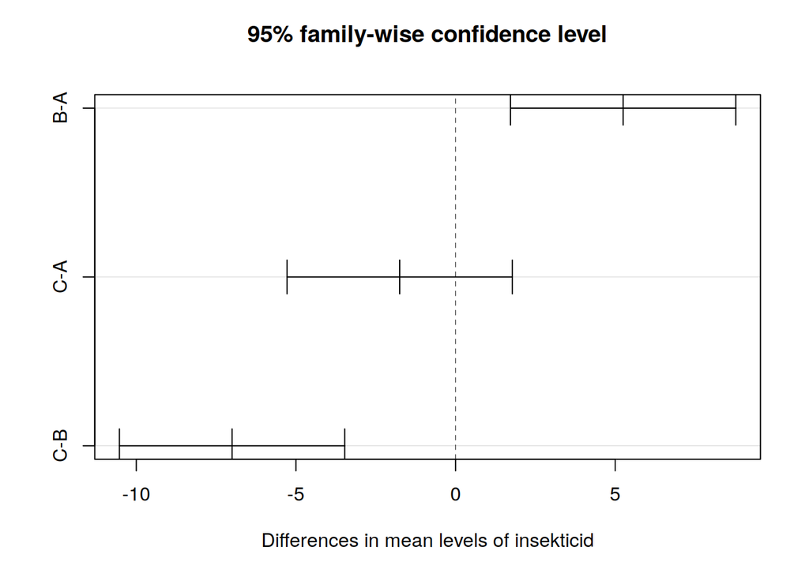

```r
plot( TukeyHSD(ANOVA) )  # rovnako pre Scheffeho post-hoc test
```

Podobne možno aplikovať dobre známy t.test na všetky dvojice a zvoliť si metódu korekcie p-hodnoty, napr. tú najznámejšiu - Bonferroniho:

```r
pairwise.t.test(dat$ucinnost, g=dat$insekticid, p.adjust.method = "bonferroni", var.equal=TRUE)
```

```
##
##  Pairwise comparisons using t tests with pooled SD
##
## data:  dat$ucinnost and dat$insekticid
##
##   A      B
## B 0.0074 -
## C 0.5985 0.0011
##
## P value adjustment method: bonferroni
```

V neparametrickej verzii:

```r
pairwise.wilcox.test(dat$ucinnost, g = dat$insekticid,
                     p.adjust.method = "bonferroni", exact = FALSE)
```

```
##
##  Pairwise comparisons using Wilcoxon rank sum test with continuity correction
##
## data:  dat$ucinnost and dat$insekticid
##
##   A     B
## B 0.088 -
## C 0.541 0.088
##
## P value adjustment method: bonferroni
```

```r
# dunn.test::dunn.test(dat$ucinnost, g = dat$insekticid, method = "bonferroni")
```

Veľkosť efektu insekticídu na účinnosť sa v prípade jedno-faktorovej ANOVA dá kvantifikovať pomocou tzv. η<sup>2</sup> (eta squared, v rozsahu od 0 po 1):

```r
ANOVA %>% summary() %>% getElement(1) %>% getElement("Sum Sq") %>% {.[1]/sum(.)}
```

```
## [1] 0.7869055
```

```r
# DescTools::EtaSq(ANOVA) #
# rstatix::eta_squared(ANOVA)
```

Faktor (druh insekticídu) teda vysveľuje asi 79% variability závislej premennej (účinnosť).

**Priklad** (hmotnosť potkanov)

Potkanom bol podávaný liek a v týždenných intervaloch sa (okrem iného) pozorovala ich hmotnosť. Treba rozhodnúť, či je vplyv lieku na zvyšovanie hmotnosti potkanov významný.

```r
dat <- data.frame(
  id = as.factor(1:5),
  t1 = c(169,180,168,174,165),
  t2 = c(170,180,176,177,172),
  t3 = c(171,185,174,190,182),
  t4 = c(176,196,180,190,182)
)
```

Pre použitie niektorých metód dáta musia byť v čistom, tzv. *long* formáte:

```r
dat <- tidyr::pivot_longer(dat, cols = t1:t4,
                           names_to = "týždeň", values_to = "hmotnosť"
)
```

Zobrazenie meraní (hmotnosti) s odlíšením štatistických jednotiek (potkanov):

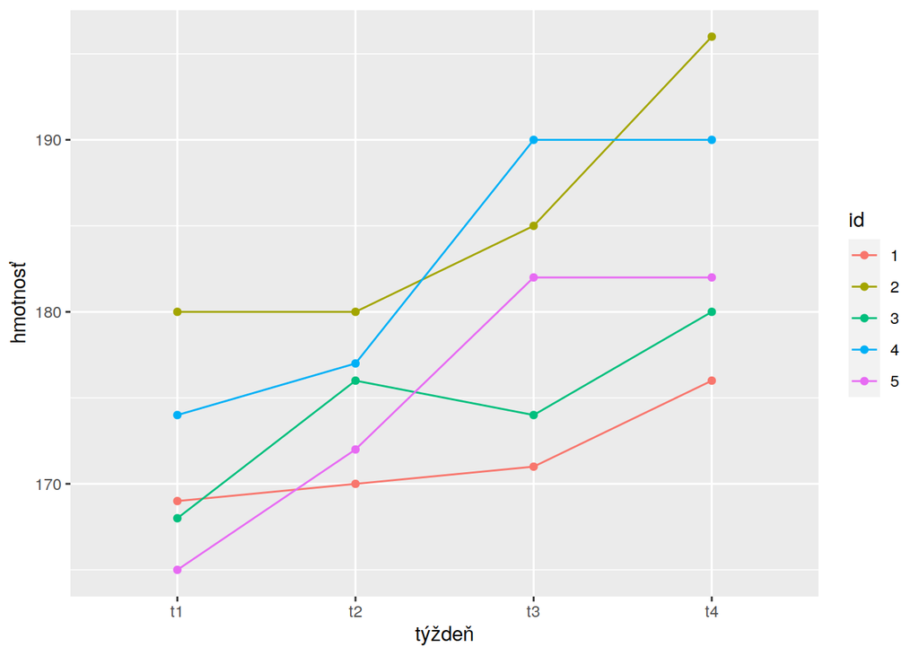

```r
library(ggplot2)
ggplot(dat, aes(x = týždeň, y = hmotnosť, group = id, color = id)) +
  geom_point() + geom_line()
```

Ak sa zanedbá fakt, že merania sú závislé (pozorované na jednej štatistickej jednotke), analýza rozptylu by viedla k nesprávnemu výsledku a (na hladine významnosti 1%) k nesprávnemu záveru: nezamietnutiu nulovej hypotézy.

```r
aov(hmotnosť ~ týždeň, data = dat) %>% summary()
```

```
##             Df Sum Sq Mean Sq F value Pr(>F)
## týždeň       3  535.7   178.6   4.031 0.0259 *
## Residuals   16  708.8    44.3
## ---
## Signif. codes:  0 '***' 0.001 '**' 0.01 '*' 0.05 '.' 0.1 ' ' 1
```

Analýza rozptylu rešpektujúca závislé (opakované) merania sa označuje aj ako *repeated measures ANOVA* alebo *within-subject ANOVA*.

```r
ANOVA <- aov(hmotnosť ~ týždeň + Error(id/týždeň), data = dat)
summary(ANOVA)
```

```
##
## Error: id
##           Df Sum Sq Mean Sq F value Pr(>F)
## Residuals  4  548.3   137.1
##
## Error: id:týždeň
##           Df Sum Sq Mean Sq F value   Pr(>F)
## týždeň     3  535.7  178.58   13.35 0.000394 ***
## Residuals 12  160.5   13.38
## ---
## Signif. codes:  0 '***' 0.001 '**' 0.01 '*' 0.05 '.' 0.1 ' ' 1
```

Tu už nulovú hypotézu môžeme zamietnuť - máme dôkaz, že liek ovplyvňuje hmotnosť potkanov. Ako veľkosť efektu (effect size) faktoru (týždeň) sa pri ANOVA s opakovanými meraniami používa tzv. zovšeobecnené eta2 (pre vysvetlenie rozdielu medzi eta2, parciálnym eta2 a zovšeobecneným eta2 pozri Bakeman, 2015)

```r
DescTools::EtaSq(ANOVA, type = 1)["týždeň", "eta.sq.gen"]
```

```
## [1] 0.4304769
```

Žiaľ, pre výstup funkcie aov() nie sú dostupné nástroje pre post-hoc testy ani test splnenia predpokladov homogenity variancie medzi skupinami (tzv. sféricita). Riešením je pozrieť sa na problém z pohľadu štatistických modelov (linear mixed effect model, pozri napr. Gribble, 2009), alebo použiť balík *rstatix* (www.datanovia.com/en/lessons/repeated-measures-anova-in-r) s používateľsky príjemnejším zápisom argumentov i výpisom výsledkov v podobe ANOVA tabuľky (so zovšeobecnenou mierou efektu – generalized effect size – *ges*) a Mauchlyho testu sféricity:

```r
ANOVA <- rstatix::anova_test(dat, dv = hmotnosť, wid = id, within = týždeň)
ANOVA[1:2]
```

```
## $ANOVA
##   Effect DFn DFd      F        p p<.05  ges
## 1 týždeň   3  12 13.352 0.000394     * 0.43
##
## $`Mauchly's Test for Sphericity`
##   Effect     W    p p<.05
## 1 týždeň 0.361 0.75
```

Viacnásobné porovnanie pomocou *párového* t-testu:

```r
pairwise.t.test(dat$hmotnosť, g = dat$týždeň, paired = TRUE, alternative = "greater")
```

```
##
##  Pairwise comparisons using paired t tests
##
## data:  dat$hmotnosť and dat$týždeň
##
##    t1     t2     t3
## t2 0.1134 -      -
## t3 0.0791 0.1134 -
## t4 0.0056 0.0280 0.1134
##
## P value adjustment method: holm
```

a graficky:

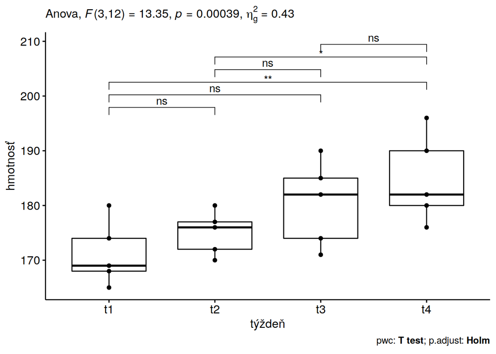

```r
tmp <- dat %>%
  rstatix::pairwise_t_test(hmotnosť ~ týždeň, paired = TRUE, alternative = "less") %>%
  rstatix::add_xy_position(x = "týždeň")
ggpubr::ggboxplot(dat, x = "týždeň", y = "hmotnosť", add = "point") +
  ggpubr::stat_pvalue_manual(tmp) +
  labs(
    subtitle = rstatix::get_test_label(ANOVA, detailed = TRUE),
    caption = rstatix::get_pwc_label(tmp)
  )
```

Podmienka normality je splnená (aspoň nie je dôkaz o opaku)

```r
dat %>%
  dplyr::group_by(týždeň) %>%
  dplyr::summarize(p.value = shapiro.test(hmotnosť)$p.value)
```

```
## # A tibble: 4 x 2
##   týždeň p.value
##   <chr>    <dbl>
## 1 t1       0.660
## 2 t2       0.833
## 3 t3       0.756
## 4 t4       0.708
```

no ak by nebola, k dispozícii je neparametrická verzia testu

```r
friedman.test(hmotnosť ~ týždeň | id, dat)
```

```
##
##  Friedman rank sum test
##
## data:  hmotnosť and týždeň and id
## Friedman chi-squared = 12.957, df = 3, p-value = 0.00473
```

a analogicky viacnásobné porovanie s korekciou p-hodnoty:

```r
dat %>% rstatix::wilcox_test(hmotnosť ~ týždeň, paired = TRUE)
```

```
## # A tibble: 6 x 9
##   .y.      group1 group2    n1    n2 statistic     p p.adj p.adj.signif
## * <chr>    <chr>  <chr>  <int> <int>     <dbl> <dbl> <dbl> <chr>
## 1 hmotnosť t1     t2         5     5         0 0.1   0.347 ns
## 2 hmotnosť t1     t3         5     5         0 0.062 0.347 ns
## 3 hmotnosť t1     t4         5     5         0 0.058 0.347 ns
## 4 hmotnosť t2     t3         5     5         2 0.188 0.362 ns
## 5 hmotnosť t2     t4         5     5         0 0.062 0.347 ns
## 6 hmotnosť t3     t4         5     5         0 0.181 0.362 ns
```

```r
# pairwise.wilcox.test(dat$hmotnosť, dat$týždeň, paired = TRUE, exact = F)
```

Tu je dobré si všimnúť zdanlivý rozpor medzi globálnym testom a post-hoc testami. To však môže indikovať len nedostatok údajov a nízku silu testu. Podľa neadjustovaných p-hodnôt výrazné rozdiely sú pri väčších časových rozostupoch.

#### 4.2.2.2 Dvojfaktorová ANOVA

**Priklad** (laborant-pristroj, zdroj: neznámy)

Traja laboranti urobili dve opakované merania diethylenglykolu na štyroch chromatografoch. Má na výsledky vplyv laborant, prístroj?

```r
dat <- data.frame(
  DEG = c(0.11, 0.106, 0.101, 0.102, 0.108, 0.109, 0.104, 0.1, 0.112, 0.111, 0.115, 0.106, 0.111, 0.109, 0.102, 0.11, 0.114, 0.112, 0.107, 0.109, 0.113, 0.11, 0.103, 0.104),
  laborant = rep(letters[1:3], c(8,9,7)),
  prístroj = rep( rep(LETTERS[1:4], each = 2), times = 3)
)
head(dat)
```

```
##     DEG laborant prístroj
## 1 0.110        a        A
## 2 0.106        a        A
## 3 0.101        a        B
## 4 0.102        a        B
## 5 0.108        a        C
## 6 0.109        a        C
```

vizualizácia rozdelenia meraní po jednotlivých faktoroch

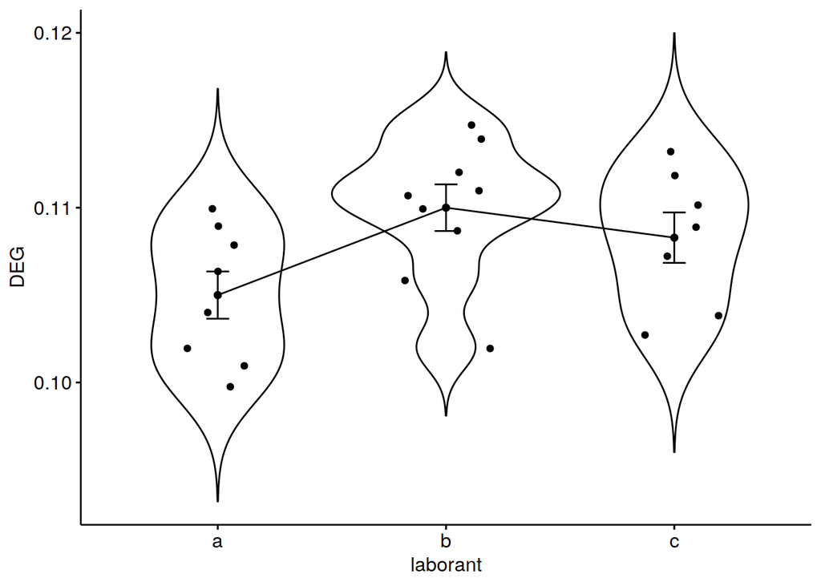

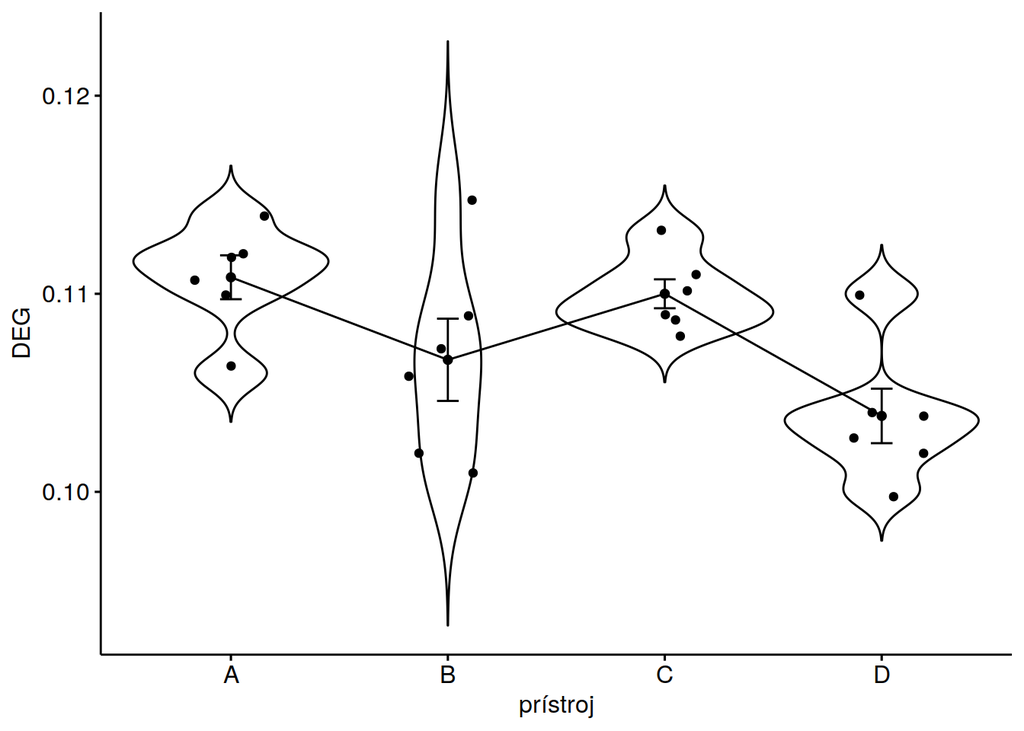

```r
# ggplot(dat, aes(x = laborant, y = DEG)) + geom_violin() + geom_point() +
#   stat_summary(geom = "errorbar", fun.data = "mean_se", width=0.2)
library(ggpubr)  # balík pre zjednodušenie štatistických grafov v ggplot
ggline(dat, x = "laborant", y = "DEG", add = c("mean_se", "violin", "jitter"))
ggline(dat, x = "prístroj", y = "DEG", add = c("mean_se", "violin", "jitter"))
detach("package:ggpubr", unload = TRUE)
```

Predpokladáme normalitu výberu a homogenitu rozptylu vo všetkých prienikoch tried faktorov. Testovať ich na tak malých vzorkách nemá veľmi zmysel, normalitu však overíme po teste (na rezíduách lineárneho modelu, ktorý funkcia aov() odhaduje).  
test ANOVA:

```r
ANOVA <- aov(DEG ~ laborant + prístroj, dat)
ANOVA %>% summary()
```

```
##             Df    Sum Sq   Mean Sq F value  Pr(>F)
## laborant     2 0.0001079 5.395e-05   6.988 0.00568 **
## prístroj     3 0.0001785 5.948e-05   7.704 0.00162 **
## Residuals   18 0.0001390 7.720e-06
## ---
## Signif. codes:  0 '***' 0.001 '**' 0.01 '*' 0.05 '.' 0.1 ' ' 1
```

Vplyv oboch faktorov na meranie DEG je významný. Overenie normality:

```r
ANOVA %>% residuals %>% shapiro.test() %>% getElement("p.value")
```

```
## [1] 0.233786
```

Post-hoc porovnanie podobne ako pri jednofaktorovej ANOVA:

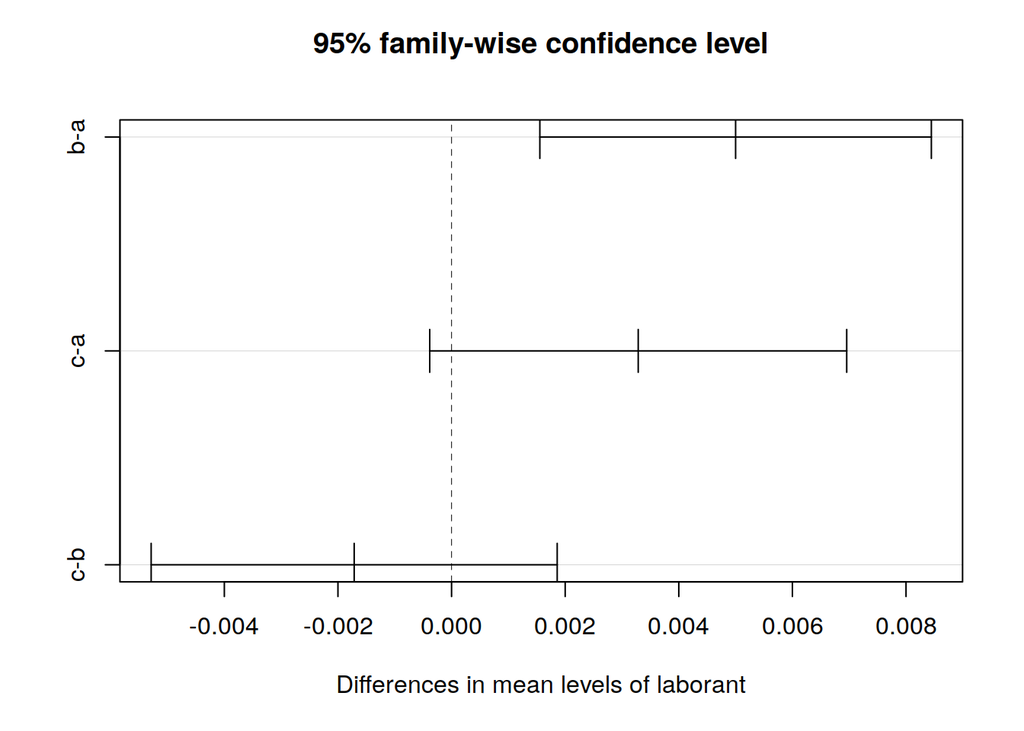

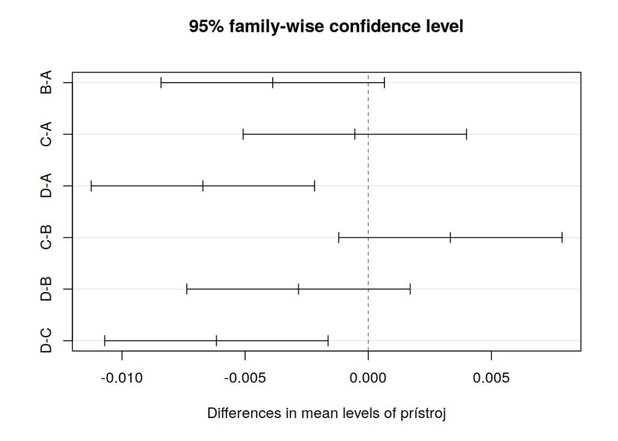

```r
ANOVA %>% TukeyHSD() %>% plot()
```

Faktory môžu na DEG vplývať aj v súčinnosti, napr. laboranti môžu byť na prístroje zvyknutí každý inak. Preto sa okrem jednotlivých vplyvov vyšetruje aj vplyv tzv. interakcie. Najprv vizuálne

```r
tmp <- dat %>%
  dplyr::group_by(laborant, prístroj) %>%
  dplyr::summarize(DEG = mean(DEG))
```

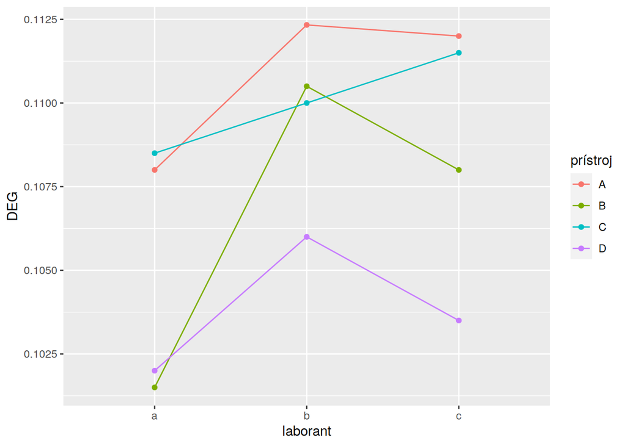

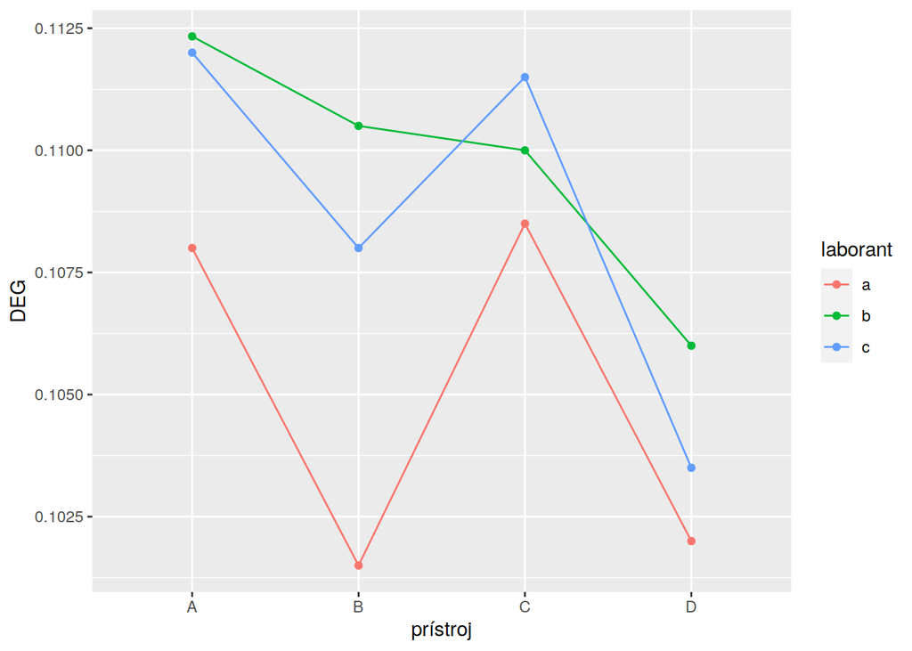

```r
ggplot(tmp, aes(x = laborant, y = DEG, color = prístroj, group = prístroj)) +
  geom_point() + geom_line()  # pozri afex::afex_plot
ggplot(tmp, aes(x = prístroj, y = DEG, color = laborant, group = laborant)) +
  geom_point() + geom_line()
detach("package:ggplot2")
```

(vplyv interakcie nebude veľmi silný) a vzápätí analyticky:

```r
ANOVA <- aov(DEG ~ laborant*prístroj, dat)
ANOVA %>% summary()
```

```
##                   Df    Sum Sq   Mean Sq F value  Pr(>F)
## laborant           2 1.079e-04 5.395e-05   6.276 0.01364 *
## prístroj           3 1.785e-04 5.948e-05   6.919 0.00587 **
## laborant:prístroj  6 3.581e-05 5.970e-06   0.694 0.65932
## Residuals         12 1.032e-04 8.600e-06
## ---
## Signif. codes:  0 '***' 0.001 '**' 0.01 '*' 0.05 '.' 0.1 ' ' 1
```

Interakčný člen nie je štatisticky významný. Veľkosť efektu jednotlivých členov vyjadruje v globále miera `eta2` a čiastkovo miera `partial.eta2`:

```r
ANOVA %>% summary() %>% getElement(1) %>% {sapply(row.names(.)[-4], function(x) c(
  eta2 = .[x,"Sum Sq"]/sum(.["Sum Sq"]),
  partial.eta2 = .[x,"Sum Sq"]/sum(.[c(x,"Residuals        "),"Sum Sq"])
))} %>% round(3)
```

```
##              laborant          prístroj          laborant:prístroj
## eta2                     0.254             0.420             0.084
## partial.eta2             0.511             0.634             0.258
```

```r
# DescTools::EtaSq(ANOVA, type = 1)
```

## 4.3 Literatúra

**Knihy**

- Kalina a kol. (2010) - Základy pravdepodobnosti a matematickej štatistiky (online iba kapitola 11, https://cran.r-project.org/doc/contrib/FundamentalsOfProbAndMStatistics-Slovak.pdf)
- Litschmannová (2011) - Úvod do statistiky (http://mi21.vsb.cz/modul/uvod-do-statistiky)
- Litschmannová - Úvod do statistiky (interaktivní učební text) - Řešené příklady
- Markechová a kol. (2011) - Úvod do štatistiky pre pedagógov (http://www.km.fpv.ukf.sk/upload_publikacie/20120130_90405__1.pdf)
- Markechová a kol. (2011) - Štatistické metódy a ich aplikácie (https://www.researchgate.net/profile/Dagmar_Markechova)
- Mangiafico (2016) - Summary and Analysis of Extension Program Evaluation in R (http://rcompanion.org/handbook/)
- Pavlík a kol. (2005) - Aplikovaná statistika.
- Verzani
  - 2002. - Simple R (https://www.math.csi.cuny.edu/Statistics/R/simpleR/index.html)
  - 2005. - Using R for Introductory Statistics (http://cbb.sjtu.edu.cn/~mywu/bi217/usingR.pdf)

**Iné zdroje**

- Bakeman (2015) - Recommended effect size statistics for repeated measures designs (https://link.springer.com/content/pdf/10.3758/BF03192707.pdf)
- Gribble (2009) - Repeated measures ANOVA using R (https://gribblelab.wordpress.com/2009/03/09/repeated-measures-anova-using-r/)